# ATELIER 2 : DEMOGRAPHIE

Auteur·rice

ESSE Kanga Bernardi, MOYOU Jeanne Dominique, YOH Oulai Munné-Prisca

Date de publication

2025-05-27

> Exemple de traitement réalisé par les groupes d’auditeur à partir de l’enquête AfroMapR.

# 1. Préparation des données

## Choix des variables à analyser

On sélectionne dans le tableau une variable Y que l’on veut expliquer et une variables X qui peut servir à expliquer Y. On décide par exemple d’examiner les variables suivantes :

- **Y : statut** : statut matrimonial
- **X : raison** : motif de la présence au marché de Bouaké

## Recodage éventuel des étiquettes

On peut raccourcir ou modifier les étiquettes pour faciliter leur affichage ou fusionner des modalités trop peu nombreuses. Ici on a décidé de regrouper les personnes mariées et divorcées. On a également regroupé les personnes autres que les commerçants et les grossistes dans une seule catégéorie *autre*

# 2. Analyse de la variable à expliquer Y

## Fréquence simple

| Modalité | Fréquence |
| --- | --- |
| Célibataire | 21 |
| Marié-Divorcé | 93 |
| Sum | 114 |

## Pourcentage

| Modalité | % |
| --- | --- |
| Célibataire | 18.4 |
| Marié-Divorcé | 81.6 |
| Sum | 100.0 |

## Diagramme en bâtons

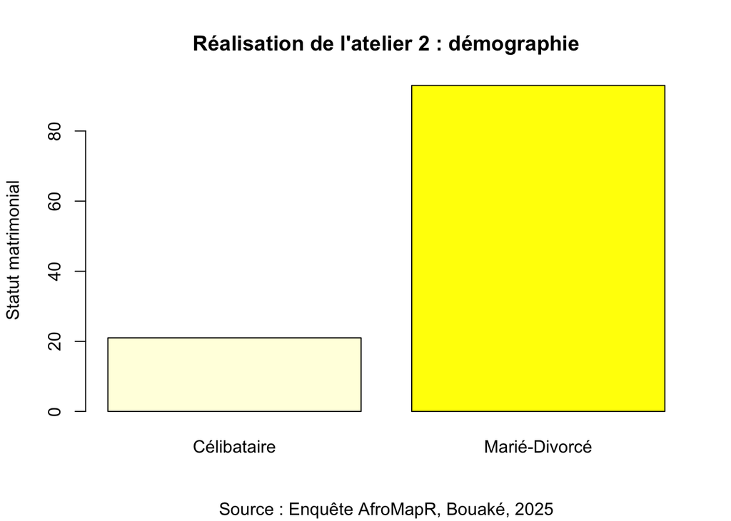

# 3. Analyse de la variable explicative X

## Fréquence simple

| Modalité | Fréquence |
| --- | --- |
| Autre | 37 |
| Commerçant | 44 |
| Grossiste | 33 |
| Sum | 114 |

## Pourcentage

| Modalité | % |
| --- | --- |
| Autre | 32.5 |
| Commerçant | 38.6 |
| Grossiste | 28.9 |
| Sum | 100.0 |

## Diagramme en bâtons

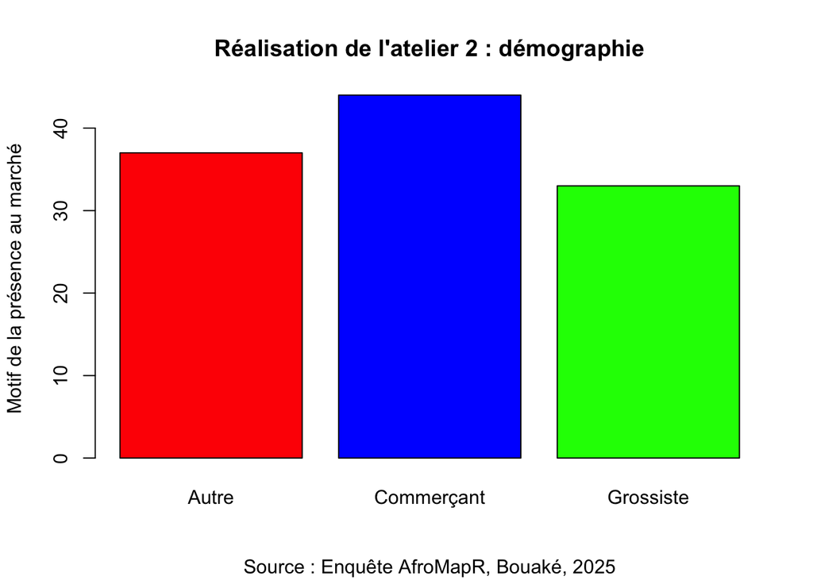

# 4. Relation entre X et Y

## Hypothèses

On veut tester l’existence d’une relation entre les deux variables précédentes.

- **H0** : Il n’y a pas de relation entre X et Y
- **H1** : Il y a une relation entre X et Y
- **Justification de l’hypothèse H1** : On suppose que les personnes mariées ont moins de risque d’insécrurité alimentaire que les personnes célibataires vivant seules.

## Tableau de contingence

|  | Célibataire | Marié-Divorcé | Sum |
| --- | --- | --- | --- |
| Autre | 14 | 23 | 37 |
| Commerçant | 4 | 40 | 44 |
| Grossiste | 3 | 30 | 33 |
| Sum | 21 | 93 | 114 |

## Pourcentage en ligne

|  | Célibataire | Marié-Divorcé | Sum |
| --- | --- | --- | --- |
| Autre | 37.8 | 62.2 | 100 |
| Commerçant | 9.1 | 90.9 | 100 |
| Grossiste | 9.1 | 90.9 | 100 |
| Sum | 18.4 | 81.6 | 100 |

On constate que les commerçants et grossistes sont les plus souvent mariés ou divorcés (91%). Mais les autres personnes présentes sur le marché (transporteurs, visiteurs, clients, …) le sont beaucoup moins (62%)

## Graphique en mosaïque

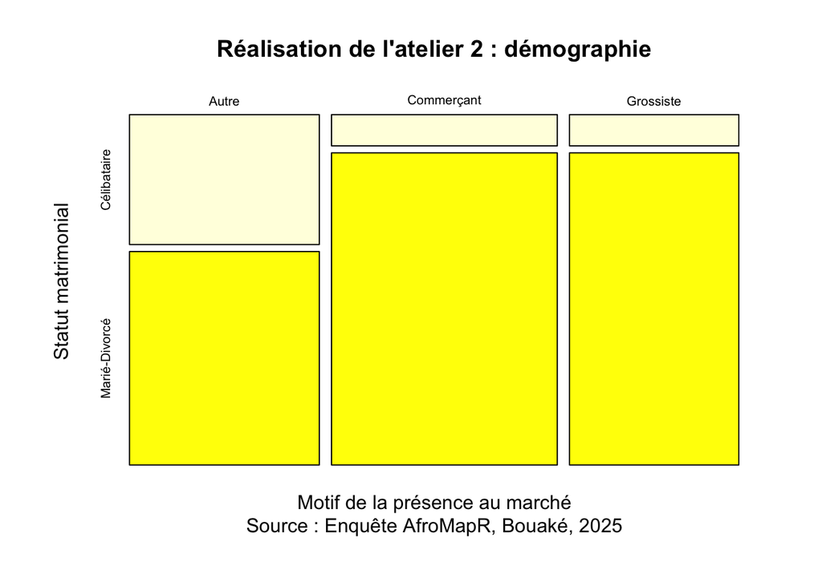

## Test du chi-2

On part de l’hypothèse nulle H0 : il n’y a pas de relation entre X et Y. Les variations en Y en fonction de X sont l’effet du hasard.

On effectue un test du chi-2 qui donne les résultats suivants :

```
    Pearson's Chi-squared test

data:  tabcont
X-squared = 13.743, df = 2, p-value = 0.001037
```

## Conclusion

Il y a environ une chance sur mille que la relation soit l’effet du hasard. On peut donc clairement rejeter H0 (p < 0.05) et affirmer qu’il existe bien une différence significative de statut matrimonial selon les raisons de la présence au marché.

L’explication des différences réside sans doute dans l’âge plus jeune des membres de la catégorie “Autre”.